# PW 1

Data Preprocessing and First Machine Learning Project in R Step-By-Step

FHS

2022-08-24

## Data Preprocessing in R

Data preprocessing is the initial phase of Machine Learning where data is prepared for machine learning models. This part is crucial and needs to be performed properly and systematically. If not, we will end up building models that are not accurate for their purpose.

In this lab, we will learn main steps that are involved in the data preprocessing course

**1.** Install the `caTools` packages into `R`.

**2.** Load the `dataset.csv` file using `read.csv`.

**3.** Take a look at our data using the `view()` function.

From the dataset, the Age and Salary column report missing data. Before implementing our machine learning models, this problem needs to be solved, otherwise it will cause a serious problem to our machine learning models. Therefore, it’s our responsibility to ensure this missing data is eliminated from our dataset using the most appropriate technique.

In our dataset, the Country column is Categorical data with 3 levels i.e. France, Spain, and Germany. The purchased column is Categorical data as well with 2 categories, i.e. YES and NO.

The machine models we built on our dataset are based on mathematical equations and it’s only take numbers in those equations.

**5.** Encode Salary the Country column using 1,2 and 3 integers

**6.** Do the same for the purchased column.

In machine learning, we split data into two parts:

-Training set: The part of the data that we implement our machine learning model on.

-Test set: The part of the data that we evaluate the performance of our machine learning model on.

The reason we split this data is to ensure that our machine learning model does not overlearn the correlation of data it’s trained on. If we let it learn too much on the data, it may perform poorly when tested on a new dataset with a different correlation.

Therefore, whenever we are building a machine learning model, the idea is to implement it on the training set and evaluate it on the test set. We expect the performance in the training set and test set to be different and if this is the case the model can adapt to new datasets.

**6.** Split the dataset into training and test sets.

It’s a common case that in most datasets, features also known as inputs, are not on the same scale. Many machine learning models are Euclidian distant-based.

It happens that, the features with the large units dominate those with small units when it comes to calculation of the Euclidian distance and it will be as if those features with small units do not exist.

To ensure this does not occur, we need to encode our features so that they all fall in the range between -3 and 3. There are several ways we can use to scale our features. The most used one is the standardization and normalization technique.

The normalization technique is used when the data is normally distributed while standardization works with both normally distributed and the data that is not normally distributed.

The formula for these two techniques is shown below.

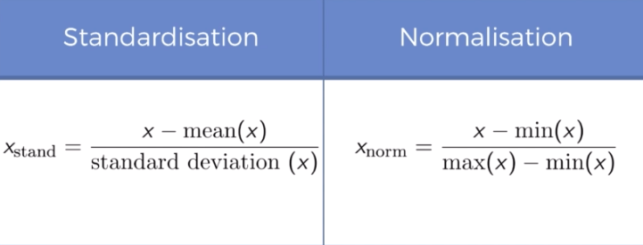

**7.** Scale both the training set and test set of our dataset separately.

Our data is now well prepared to give Machine Learning models that can predict future outcomes effectively.

## First Machine Learning Project in R Step-By-Step

We are going to use the iris flowers dataset. This dataset is famous because it is used as the “hello world” dataset in machine learning and statistics by pretty much everyone.

The dataset contains 150 observations of iris flowers. There are four columns of measurements of the flowers in centimeters. The fifth column is the species of the flower observed. All observed flowers belong to one of three species.

**1.** Fortunately, the R platform provides the iris dataset for us. Load the dataset using `data` function or load it using read_csv as before.

We need to know that the model we created is any good.

Later, we will use statistical methods to estimate the accuracy of the models that we create on unseen data. We also want a more concrete estimate of the accuracy of the best model on unseen data by evaluating it on actual unseen data. That is, we are going to hold back some data that the algorithms will not get to see and we will use this data to get a second and independent idea of how accurate the best model might actually be.

**2.** Split the loaded dataset into two, 80% of which we will use to train our models and 20% that we will hold back as a validation dataset (use the createDataPartition function from caret packages)

**3.** Use the `dim`, `summary`, `sapply`, `head`, `levels` functions to summarize your dataset.

**4.** Take a look at the number of instances (rows) that belong to each class using `table.prop`.

We now have a basic idea about the data. We need to extend that with some visualizations.

We are going to look at two types of plots:

-Univariate plots to better understand each attribute.

-Multivariate plots to better understand the relationships between attributes.

**5.** Create box plots of each mesure variable.

**6.** Create a barplot of the Species class variable to get a graphical representation of the class distribution.

**7.** Now look at the interactions between the variables using `scatterplots` and `featurePlot` of all pairs of attributes. Note that scatterplots s draw ellipses to presenent an approximation of the points distribution and a confident interval.

Now it is time to create some models of the data and estimate their accuracy on unseen data.

Here is what we are going to cover in this step:

- Set-up the test harness to use 10-fold cross validation.
- Build 3 different models to predict species from flower measurements
- Select the best model.

First, We will 10-fold crossvalidation to estimate accuracy.

This we split our dataset into 10 parts, train in 9 and test on 1 and release for all combinations of train-test splits. We will also repeat the process 3 times for each algorithm with different splits of the data into 10 groups, in an effort to get a more accurate estimate. note that we will use the metric of “Accuracy” to evaluate models. This is a ratio of the number of correctly predicted instances in divided by the total number of instances in the dataset multiplied by 100 to give a percentage (e.g. 95% accurate). We will be using the metric variable when we run build and evaluate each model next.

**8.** Using `trainControl` function to define the cv mechanism

We don’t know which algorithms would be good on this problem or what configurations to use. We get an idea from the plots that some of the classes are partially linearly separable in some dimensions, so we are expecting generally good results.

**9.**Evaluate 3 the different algorithms knn,svm and rf (one of them will be seen in future chapters):

- k-Nearest Neighbors (kNN).
- Support Vector Machines (SVM) with a linear kernel.
- Random Forest (RF)

**10.** Report on the accuracy of each model by first creating a list of the created models and using the summary function. you can use the caret packages documentation

**11.** Create a plot of the model evaluation results and compare the spread and the mean accuracy of each model.

**12.** Find the best model and maake a prediction with it.

◼